# arch

[figure not shown]

Acharya N.G. Ranga Agricultural University

Agricultural College, Bapatla

Department of Statistics and Computer Applications

AECO 606 ADVANCED AGRICULTURAL MARKETING AND PRICE ANALYSIS

Autoregressive Conditional Heteroscedasticity

Presenter Krupesh S (BAD/2025-25) I Ph.D.(Ag.) Agricultural Statistics

## Characteristics of Economic Time Series

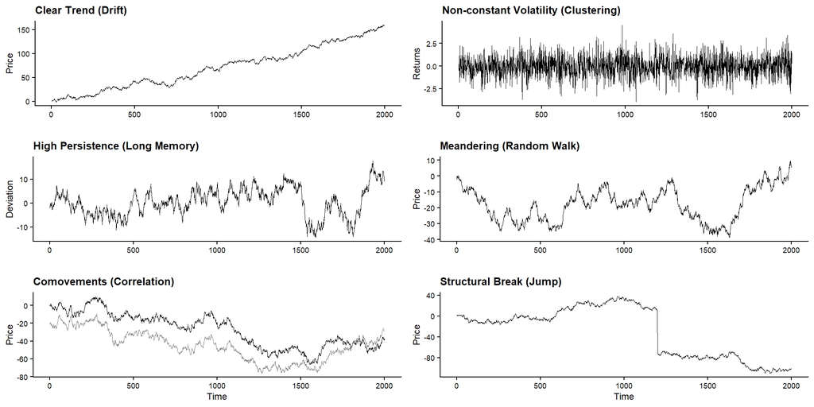

# OBJECTIVE

## Volatility

Volatility means the conditional standard deviation of the underlying price return.

**Implied they say!**

The volatility value that, when plugged into a theoretical pricing model, reproduces the observed market price of an asset is termed as *implied volatility*

## Characteristics of Volatility

**Unobservability**

- Volatility is *not directly observable* — only one return per trading day exists
- Implied volatility is model-dependent and often overstates true volatility

**Volatility Clustering**

- High volatility periods and low volatility periods tend to cluster together

**Continuous Evolution**

- Volatility changes smoothly over time — abrupt jumps are rare

**Mean Reversion (Stationarity)**

- Volatility does not diverge to $\infty$ — it fluctuates within a bounded range

**Leverage Effect**

- Volatility reacts *asymmetrically* to price increases vs. price drops

## Why Volatility?

The price level reveals the market’s current valuation of a commodity, while volatility captures the uncertainty and risk embedded in the price discovery process that led to that equilibrium.

## Homoscedastic vs Heteroscedastic Process

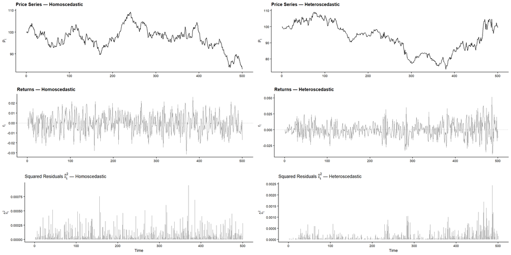

# THE OLS SETUP

## Problem

- Many economic time series exhibit periods of unusually large volatility followed by periods of relative tranquility.
- In such circumstances, the assumption of a constant variance (homoscedasticity) is inappropriate.

## Model

One approach to model this behaviour is to explicitly introduce an independent variable $x_i$ such that,
$$y_{t+1} = \epsilon_{t+1}x_t
\tag{1}$$
where,
$y_{t+1}$ is the dependent variable of interest;
$\epsilon_{t+1}$ is a white-noise disturbance term with variance $\sigma^2$;
$x_t$ is an independent variable that can be observed at period $t$.
Here,
$$var(y_{t+1}|x_t) = x_t^2\sigma^2
\tag{2}$$

## Logarithmic Form

Modifying the Equation 1, we get,
$$\ln(y_t) = \alpha_0 + \alpha_1 \ln(x_{t-1}) + e_t
\tag{3}$$
where, $e_t=\ln(\epsilon_t)$

## Regression and its Limitations

Since Equation 3 is linear, OLS can be used to estimate the parameters $\alpha_0$ and $\alpha_1$.

But,

- The model forces ${x_t}$ to affect mean of $\ln(y_t)$:

  It is difficult to choose one candidate for ${x_t}$ over many reasonable choices.
- Transformations are required for the series to have a constant variance.

# THE ARCH PROCESS

## The “Conditional” Advantage

Consider a stationary ARMA model,
$$y_t = a_0 + a_1y_{t-1} + \epsilon_t$$

| Expectation Type | Mean | Forecast Error Variance |
| --- | --- | --- |
| Conditional | \(E_t y_{t+1} = a_0 + a_1 y_t\) | \(E_t[(y_{t+1} - a_0 - a_1 y_t)^2] = E_t\epsilon_{t+1}^2 = \sigma^2\) |
| Unconditional | \(Ey_{t+1} = \dfrac{a_0}{1-a_1}\) | \(E\left[\left(y_{t+1} - \dfrac{a_0}{1-a_1}\right)^2\right] = \dfrac{\sigma^2}{1-a_1^2}\) |

The conditional forecast uses information from the past and its variance is certainly less than the unconditional counterpart. Thus conditional forecasts are preferable.

## Modelling Non-constant variance

When the conditional variance is not constant, a simple strategy is to model the conditional variance as an AR($q$) process using squares of the estimated residuals:
$$\hat{\epsilon}_t^2 = \alpha_0 + \alpha_1\hat{\epsilon}_{t-1}^2 + \alpha_2\hat{\epsilon}_{t-2}^2 + \cdots + \alpha_q\hat{\epsilon}_{t-q}^2 + v_t \tag{4}$$
where $v_t$ is a white-noise process.

If the values of $\alpha_1, \alpha_2, ..., \alpha_n$ all equal to zero, the estimated variance is simply the constant $\alpha_0$.

**ARCH ALERT**

The model in Equation 4 is the stepping stone to the ARCH process

# ENGLE’S ARCH SPECIFICATION

## The Flaw with additive model

- In Equation 4, $\hat{\epsilon}_{t}^2$ should be strictly non-negative. Also the coefficients are constrained to be non-negative to ensure the expected variance stays positive.
- However, $\nu_t$ is a white-noise process, it can take negative values. If there is a sufficiently large negative shock on $\nu_t$, the entire right hand side of Equation 4 can become mathematically negative.

## The Multiplicative Alternative

In 1982, Robert. F. Engle proposed a class of multiplicative models as:
$$\epsilon_t = v_t \sqrt{\alpha_0 + \sum_{i=1}^q \alpha_i \epsilon_{t-i}^2} \tag{5}$$
which is known to be the ARCH($q$) process with $\alpha_0 > 0$, $\alpha_i \geq 0$ and $\sum\alpha_i < 1$.

## Deriving the Conditional Variance

Starting from Equation 5:

$$\epsilon_t = v_t\sqrt{\alpha_0 + \sum_{i=1}^q \alpha_i \epsilon_{t-i}^2}$$

Taking $\text{Var}(\cdot \mid \mathcal{F}_{t-1})$ on both sides:

$$\text{Var}(\epsilon_t \mid \mathcal{F}_{t-1})
= \left(\alpha_0 + \sum_{i=1}^q \alpha_i \epsilon_{t-i}^2\right)
\cdot \underbrace{\text{Var}(v_t)}_{ = 1}$$

$$\therefore \quad \boxed{\sigma_t^2 = \alpha_0 + \sum_{i=1}^q \alpha_i \epsilon_{t-i}^2} \tag{6}$$

## Compact Form of ARCH($q$)

Substituting $\sigma_t^2 = \alpha_0 + \displaystyle\sum_{i=1}^q \alpha_i \epsilon_{t-i}^2$ back into Equation 5:

$$\epsilon_t = v_t\sqrt{\alpha_0 + \sum_{i=1}^q \alpha_i \epsilon_{t-i}^2}
= v_t\sqrt{\sigma_t^2} = v_t\sigma_t \tag{7}$$

where $\sigma_t > 0$, since $\alpha_0 > 0$ and $\alpha_i \geq 0$.

## Unconditional Variance of ARCH($q$)

Since $E(\epsilon_t) = 0$, we have $\text{Var}(\epsilon_t) = E(\epsilon_t^2)$.

Applying the Law of Iterated Expectations:

$$\text{Var}(\epsilon_t) = E\left[E(\epsilon_t^2 \mid \mathcal{F}_{t-1})\right] = E(\sigma_t^2) = E\left(\alpha_0 + \sum_{i=1}^q \alpha_i \epsilon_{t-i}^2\right)$$

Under stationarity, $E(\epsilon_t^2) = E(\epsilon_{t-i}^2) = \text{Var}(\epsilon_t)$ for all $i$.

Denoting $\text{Var}(\epsilon_t) = \sigma^2$:

$$\sigma^2 = \alpha_0 + \sum_{i=1}^q \alpha_i \sigma^2 \implies \sigma^2\left(1 - \sum_{i=1}^q \alpha_i\right) = \alpha_0$$

$$\boxed{\sigma^2 = \dfrac{\alpha_0}{1 - \sum_{i=1}^q \alpha_i}} \tag{8}$$

## Mean of the ARCH($q$) Process

From Equation 7, $\epsilon_t = v_t\sigma_t$, where $\sigma_t$ is $\mathcal{F}_{t-1}$-measurable.

**Conditional Mean:**
$$E(\epsilon_t \mid \mathcal{F}_{t-1}) = \sigma_t \cdot E(v_t \mid \mathcal{F}_{t-1}) = \sigma_t \cdot 0 = 0$$

since $v_t \sim \text{iid}(0,1)$ is independent of $\mathcal{F}_{t-1}$.

**Unconditional Mean:**
$$E(\epsilon_t) = E\left[E(\epsilon_t \mid \mathcal{F}_{t-1})\right] = E[0] = 0$$

by the **Law of Iterated Expectations**.

## Heavy Tails of the ARCH Process

As long as $\alpha_i \neq 0$ for at least one $i$, $\kappa > 3$, the ARCH($q$) process has  
**heavier tails than the normal distribution**, provided $\displaystyle\sum_{i=1}^q 3\alpha_i^2 < 1$ where $\kappa$ is the measure of kurtosis.

## Testing for ARCH Effects: Engle’s LM Test

$\mathbf{H_0}: \alpha_1 = \alpha_2 = \cdots = \alpha_q = 0$ (no ARCH effects)

*Step 1*: Fit an appropriate mean equation (ARMA or OLS regression) and obtain squared residuals $\{\hat{\epsilon}_t^2\}$.

*Step 2*: Regress $\hat{\epsilon}_t^2$ on its $q$ lagged values as in Equation 4:

$$\hat{\epsilon}_t^2 = \alpha_0 + \alpha_1\hat{\epsilon}_{t-1}^2 + \alpha_2\hat{\epsilon}_{t-2}^2 + \cdots + \alpha_q\hat{\epsilon}_{t-q}^2 + v_t$$

*Step 3*: Compute the test statistic. Under $H_0$:

$$NR^2 \xrightarrow{d} \chi^2(q)$$
For small samples, an $F$-test with $(q,\ N-q)$ df is preferred.

## Maximum Likelihood Estimation of ARCH($q$)

Given $N$ observations, the parameter vector is $\boldsymbol{\theta} = (\alpha_0, \alpha_1, \ldots, \alpha_q)^\top$.

**Conditional Log-Likelihood:**

Assuming $v_t \sim N(0,1)$, the conditional density of $\epsilon_t$ given $\mathcal{F}_{t-1}$ is:

$$f(\epsilon_t \mid \mathcal{F}_{t-1}) = \frac{1}{\sqrt{2\pi\sigma_t^2}}\exp\left(-\frac{\epsilon_t^2}{2\sigma_t^2}\right)$$

The conditional log-likelihood over $t = q+1, \ldots, N$ is:

$$\ell(\boldsymbol{\theta}) = -\frac{1}{2}\sum_{t=q+1}^{N}\left[\log(2\pi) + \log(\sigma_t^2) + \frac{\epsilon_t^2}{\sigma_t^2}\right]$$

## ML Algorithm

1. Initialize $\boldsymbol{\theta}^{(0)}$ — typically via OLS on $\hat{\epsilon}_t^2$ against its lags
2. At iteration $k$, evaluate $\sigma_t^2 = \alpha_0 + \sum_{i=1}^q \alpha_i \epsilon_{t-i}^2$ recursively for $t = q+1, \ldots, N$
3. Compute $\ell(\boldsymbol{\theta}^{(k)})$
4. Update $\boldsymbol{\theta}^{(k+1)}$ via **BFGS** quasi-Newton optimization
5. Repeat steps 2–4 until $\|\boldsymbol{\theta}^{(k+1)} - \boldsymbol{\theta}^{(k)}\| < \delta$

**Constraints**

Optimization is subject to $\alpha_0 > 0$, $\alpha_i \geq 0$, and $\displaystyle\sum_{i=1}^q \alpha_i < 1$ to ensure positivity of $\sigma_t^2$ and second-order stationarity.

## Effect of ARCH Coefficients

[interactive chart not shown]

**Alpha dynamics**

As $\alpha_1 + \alpha_2 \to 1$, volatility clusters intensify and tails grow heavier — the ARCH process departs increasingly from normality.

## Building an ARCH Model

1. **Compute Log Returns** — Transform raw price series $P_t$ to log returns $r_t = \ln(P_t/P_{t-1})$. This ensures stationarity in mean, removes trend, and stabilises scale.
2. **Fit a Mean Equation** — Fit an appropriate ARMA($p$,$q$) model on $r_t$ using AIC/BIC. Extract residuals $\hat{\epsilon}_t$.
3. **Test for ARCH Effects** — Run Engle’s LM test on $\hat{\epsilon}_t$. Reject $H_0$ to confirm volatility clustering warrants ARCH modelling.
4. **Identify Order $q$** — Examine PACF of $\hat{\epsilon}_t^2$. The lag at which PACF cuts off suggests candidate $q$.
5. **Estimate ARCH($q$)** — Maximise conditional log-likelihood via BFGS. Verify $\alpha_0 > 0$, $\alpha_i \geq 0$, and $\sum\alpha_i < 1$.
6. **Diagnose Residuals** — Standardise residuals as $\tilde{\epsilon}_t = \hat{\epsilon}_t/\hat{\sigma}_t$. Check:
   - ACF of $\tilde{\epsilon}_t$ and $\tilde{\epsilon}_t^2$ for remaining structure
   - Ljung-Box test on $\tilde{\epsilon}_t^2$
   - QQ-plot for distributional assumption
7. **Iterate if Needed** — If $\tilde{\epsilon}_t^2$ still shows significant ACF, increase $q$ or consider GARCH.
8. **Forecast** — Use fitted $\hat{\sigma}_t^2$ for volatility forecasting and interval construction.

# EMPIRICAL ILLUSTRATION

## Data: Deutsch Mark / British Pound Exchange Rate Returns

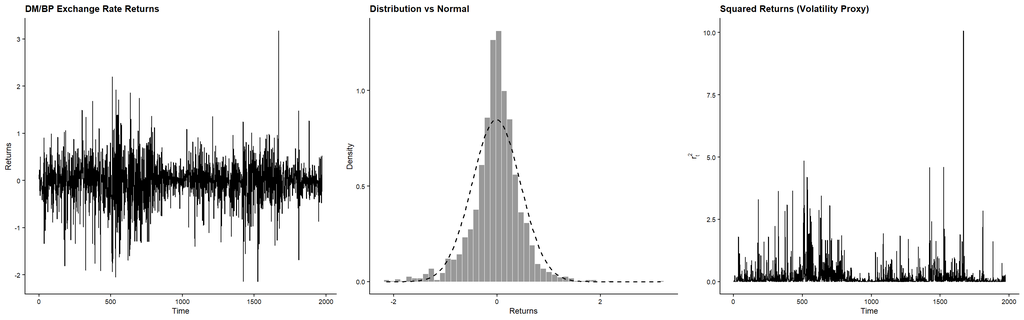

**Data**

Deutsch Mark / British Pound exchange rate returns.  
$N = 1974$ observations. Canonical dataset for ARCH demonstration.

## Step 1: Log Returns

```r
library(rugarch)
data("dmbp", package = "rugarch")
r <- dmbp[, 1]
head(r)
```

```
[1]  0.12533286  0.02887427  0.06346177  0.22671922 -0.21426695  0.20285367
```

- Series is already in log return form: $r_t = \ln(P_t / P_{t-1})$
- Mean close to zero, exhibits volatility clustering visually

## Step 2: Stationarity Test

```r
library(tseries)
adf.test(r)
```

```
    Augmented Dickey-Fuller Test

data:  r
Dickey-Fuller = -12.268, Lag order = 12, p-value = 0.01
alternative hypothesis: stationary
```

- ADF test strongly rejects $H_0$ of unit root
- Series is stationary — no differencing required

## Step 3: Fit Candidate Mean Equations

```r
models <- list(
  "AR(1)"     = arima(r, order = c(1,0,0)),
  "AR(2)"     = arima(r, order = c(2,0,0)),
  "MA(1)"     = arima(r, order = c(0,0,1)),
  "MA(2)"     = arima(r, order = c(0,0,2)),
  "ARMA(1,1)" = arima(r, order = c(1,0,1)),
  "ARMA(1,2)" = arima(r, order = c(1,0,2)),
  "ARMA(2,1)" = arima(r, order = c(2,0,1)),
  "ARMA(2,2)" = arima(r, order = c(2,0,2))
)
ic_tbl <- data.frame(
  Model = names(models),
  AIC   = round(sapply(models, AIC), 3),
  BIC   = round(sapply(models, BIC), 3)
)
ic_tbl
```

```
     Model      AIC      BIC
     AR(1) 2628.020 2644.783
     AR(2) 2628.744 2651.096
     MA(1) 2628.010 2644.774
     MA(2) 2628.720 2651.071
 ARMA(1,1) 2628.673 2651.025
 ARMA(1,2) 2629.725 2657.664
 ARMA(2,1) 2629.663 2657.602
 ARMA(2,2) 2631.408 2664.935
```

- Best mean equation by BIC: **MA(1)**
- Residuals $\hat{\epsilon}_t$ extracted for ARCH testing

## Step 4: ACF and PACF of Squared Residuals

```r
acf_r2  <- acf(resid^2,  lag.max = 12, plot = FALSE)
pacf_r2 <- pacf(resid^2, lag.max = 12, plot = FALSE)
ci      <- qnorm(0.975) / sqrt(length(resid))
```

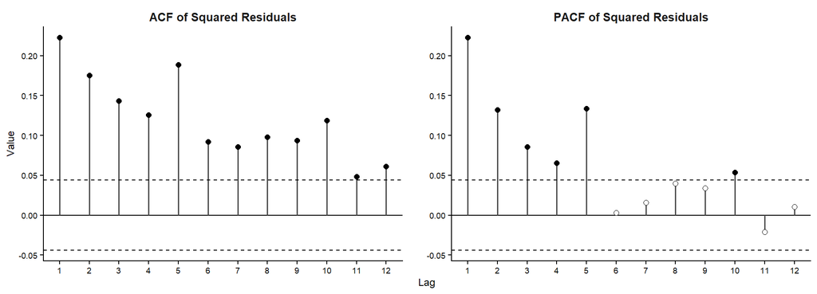

- Filled points exceed the 95% confidence band — significant lags
- PACF cuts off at lag **5** — suggests **ARCH(5)**

## Step 5: Engle’s LM Test

```r
library(FinTS)
ArchTest(resid, lags = max_lag)
```

```
    ARCH LM-test; Null hypothesis: no ARCH effects

data:  resid
Chi-squared = 183.61, df = 5, p-value < 2.2e-16
```

- $p$-value $< 0.05$ — formally confirms ARCH effects
- Maximum lag set to **5** from PACF inspection

## Step 6: Fit and Compare ARCH Orders

```r
arch_fit <- function(q) {
  spec <- ugarchspec(
    variance.model     = list(model      = "sGARCH",
                               garchOrder = c(q, 0)),
    mean.model         = list(armaOrder    = c(p_order, q_order),
                               include.mean = TRUE),
    distribution.model = "norm"
  )
  ugarchfit(spec, data = r, solver = "hybrid")
}

q_max  <- max(max_lag, 2)
fits   <- lapply(1:q_max, arch_fit)
ic_mat <- sapply(fits, infocriteria)

ic_tbl <- data.frame(
  Order = paste0("ARCH(", 1:q_max, ")"),
  AIC   = round(ic_mat[1, ], 5),
  BIC   = round(ic_mat[2, ], 5)
)
ic_tbl
```

```
   Order     AIC     BIC
 ARCH(1) 1.22652 1.23784
 ARCH(2) 1.18919 1.20334
 ARCH(3) 1.16693 1.18392
 ARCH(4) 1.15701 1.17683
 ARCH(5) 1.13999 1.16263
```

- Best model by BIC: **ARCH(5)**
- BIC preferred for stronger parsimony penalty

## Step 7: Best Model Estimates

```r
coef(best_fit)
```

```
      mu      ma1    omega   alpha1   alpha2   alpha3   alpha4   alpha5
-0.00110  0.04105  0.07880  0.24684  0.14579  0.09226  0.08572  0.12329
```

- $\hat{\alpha}_0 = 0.0788$ — baseline conditional variance
- $\sum\hat{\alpha}_i = 0.69392 < 1$ — **stationarity condition satisfied**

## Step 8: Residual Diagnostics

```r
std_resid <- residuals(best_fit, standardize = TRUE)
ArchTest(std_resid,   lags = best_q)
Box.test(std_resid,   lag  = best_q, type = "Ljung-Box")
Box.test(std_resid^2, lag  = best_q, type = "Ljung-Box")
```

```
    ARCH LM-test; Null hypothesis: no ARCH effects

data:  std_resid
Chi-squared = 2.599, df = 5, p-value = 0.7615
```

```
    Box-Ljung test

data:  std_resid
X-squared = 3.5937, df = 5, p-value = 0.6093
```

```
    Box-Ljung test

data:  std_resid^2
X-squared = 2.5756, df = 5, p-value = 0.7651
```

- LM test on $\tilde{\epsilon}_t$: $p > 0.05$ — **no remaining ARCH effects**
- Ljung-Box on $\tilde{\epsilon}_t$: $p > 0.05$ — **no linear autocorrelation**
- Ljung-Box on $\tilde{\epsilon}_t^2$: $p > 0.05$ — **white noise confirmed**

## Step 8: QQ-Plot

```r
ggplot(data.frame(r = as.numeric(std_resid)),
       aes(sample = r)) +
  stat_qq(size = 0.8, alpha = 0.6) +
  stat_qq_line(color = "black", linewidth = 0.6) +
  labs(title = "QQ-Plot: Standardised Residuals") +
  theme_classic()
```

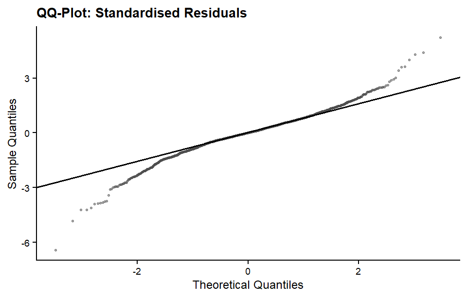

## Step 9: Volatility Forecast

```r
forc <- ugarchforecast(best_fit, n.ahead = 20)
plot(forc, which = 3)
```

[figure not shown]

- Forecast converges toward unconditional volatility
- Confirms mean-reverting nature of the fitted ARCH process

# TIMELINE OF ARCH MODEL DEVELOPMENT

| Year | Model | Author(s) | Key Contribution |
| --- | --- | --- | --- |
| 1982 | ARCH(*q*) | Engle | Time-varying conditional variance driven by past squared shocks |
| 1986 | GARCH(*p,q*) | Bollerslev | Adds lagged variance terms — parsimonious long-memory volatility |
| 1987 | ARCH-M | Engle, Lilien & Robins | Volatility enters the mean equation — formalises risk-return tradeoff |
| 1988 | IGARCH | Engle & Bollerslev | Integrated GARCH — shocks to variance are permanent |
| 1991 | EGARCH | Nelson | Exponential form — asymmetric leverage effect, no sign constraints |
| 1991 | Semi-parametric ARCH | Engle & González-Rivera | Non-parametric innovation distribution — relaxes normality assumption |
| 1992 | GJR-GARCH | Glosten, Jagannathan & Runkle | Threshold asymmetry — separates impact of positive and negative shocks |
| 1992 | News Impact Curve | Engle & Ng | Measures asymmetric impact of positive vs negative news on σ̂<sub>t</sub><sup>2</sup> |
| 1992 | Implied ARCH | Engle & Chowdhury | Extracts volatility dynamics from options prices — links ARCH with options markets |
| 1992 | MGARCH / FACTOR-ARCH | Bollerslev \| Engle, Ng & Rothschild | Multivariate conditional covariance — factor structure for large portfolios |
| 1993 | Stochastic Volatility | Harvey, Ruiz & Shephard | Latent volatility process — alternative paradigm to GARCH framework |

**Nobel Recognition**

Robert F. Engle was awarded the **Nobel Prize in Economics in 2003** for the ARCH framework and its role in modern financial econometrics.

# WEAKNESSES OF ARCH MODELS

1. **Symmetric Response** — Uses $\epsilon_{t-i}^2$, so positive and negative shocks have identical effects on volatility. Financial assets respond asymmetrically in practice.
2. **Restrictive Constraints** — For ARCH(1), $\alpha_1^2 \leq \dfrac{1}{3}$ is required for finite kurtosis. Constraints become increasingly complex at higher orders.
3. **No Causal Insight** — Mechanically describes conditional variance behaviour but gives no indication of what drives volatility clustering.
4. **Overpredicts Volatility** — Responds slowly to large isolated shocks, causing persistent overestimation of volatility after outlier events.

# THE ARCH-M MODIFICATION

## Motivation

Risk-averse agents demand compensation for holding a volatile asset — the risk premium itself should rise with conditional variance.

**The Three-Equation System** (Engle, Lilien & Robins, 1987):

$$y_t = \mu_t + \varepsilon_t \qquad \text{(Mean equation)} \tag{9}$$

$$\mu_t = \beta + \delta h_t, \quad \delta > 0 \qquad \text{(Risk premium)} \tag{10}$$

$$h_t = \alpha_0 + \sum_{i=1}^{q} \alpha_i \varepsilon_{t-i}^2 \qquad \text{(Variance equation)} \tag{11}$$

where $y_t$ is the excess return, $\mu_t$ is the time-varying risk premium, and $h_t$ is the ARCH($q$) conditional variance.

**Key Interpretations**

- $\delta > 0$ — higher conditional variance raises expected return (risk–return tradeoff)
- $\delta = 0$ — ARCH-M degenerates to standard ARCH; risk premium becomes constant $\beta$
- $\delta$ is estimated jointly with $\alpha_i$ via MLE — its significance is the central test

## How it differs from ARCH(q)

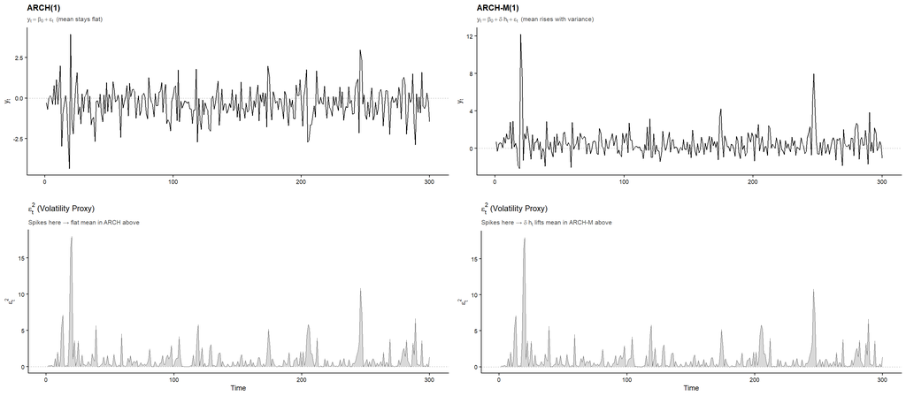

# ARCH FAMILY

## ARCH Family Explorer

[interactive chart not shown]

# REFERENCES

## REFERENCES

1. Engle, R. F. (1982). Autoregressive conditional heteroscedasticity with estimates of the variance of United Kingdom inflation. *Econometrica, 50*(4), 987–1007.

2. Engle, R. F., Lilien, D. M., & Robins, R. P. (1987). Estimating time varying risk premia in the term structure: The ARCH-M model. *Econometrica, 55*(2), 391–407.

3. Enders, W. (2015). *Applied econometric time series* (4th ed.). John Wiley & Sons.

4. Tsay, R. S. (2010). *Analysis of financial time series* (3rd ed.). John Wiley & Sons.

5. Ghalanos, A. (2025). *rugarch: Univariate GARCH models* (R package version 1.5-4).